← → 或空白鍵翻頁 · F 全螢幕

LV MURAL THROMBUS · 臨床病例教學

# 左心室 壁貼壁血栓

一位陳舊性心肌梗塞、沒有心房顫動、卻反覆中風的病人。  
答案不在頸動脈，在左心室的心尖。

2次缺血性中風 2013 · 2019

0次記錄到心房顫動

1.0 × 0.78cm 心尖血栓，2020/03 由 TTE 發現

6 yr抗凝後未再中風 2020 → 2026

心臟內科 × 神經內科案例已去識別化

學習目標

## 這堂課要你帶走六件事

- **辨識高風險族群** 哪些心臟狀況會長出左心室血栓，為什麼「前壁心肌梗塞」是關鍵字。
- **破除兩個迷思** 「沒有 Afib 就不是心因性」、「TEE 陰性就可以排除心臟血栓」——兩者都錯。
- **學會影像策略** TTE／顯影 TTE／TEE／心臟 MRI 各自的角色與盲點。
- **解讀梗塞區域** 當梗塞分佈與頸動脈病灶對不上時，該往哪裡找栓子。
- **掌握抗凝治療** INR 目標、療程長度與影像追蹤。
- **認識出血風險** 抗凝＋抗血小板＋NSAID 的三重打擊。

LV MURAL THROMBUSOBJECTIVES

案例

## 病人是誰

60 餘歲男性，高血壓、高血脂，心血管與神經科同時追蹤中。

### 心血管病史

- 2017/08 LAD 中段置放裸金屬支架（RCA 中段 50% 狹窄）。
- 2018/03 **前壁 ST 上升型心肌梗塞**，支架內再狹窄，緊急介入並置放塗藥支架。
- 此後心尖形成疤痕與動脈瘤，LVEF 降至 39–40%。

### 神經科病史

- 2013/05 首次中風，左側同側偏盲（右側內枕葉）。
- 2019/11 再次中風，左側內枕葉與左小腦梗塞。
- 歷次心電圖皆為竇性心律，從未記錄到心房顫動。

### 當年的思考路徑

「中風 → 先看頸動脈，再看有沒有心房顫動。」病人沒有 Afib，於是所有注意力都集中在頸動脈狹窄上。 兩件事被跳過了：他有一顆做過前壁大範圍梗塞的心臟，而且沒有人仔細看過他的左心室心尖。

CASE PRESENTATION60s / M

時間軸 1／2

## 從第一次中風，到第二次中風

日期本身就是論證：注意 2018 年的前壁梗塞，如何在一年後變成 2019 年的中風。

2013.05 首次中風左側同側偏盲，右側內枕葉梗塞。當時未找到明確栓子來源。

2017.08 冠狀動脈介入運動心電圖陽性，LAD 中段置放裸金屬支架。

2018.03 前壁 STEMI ─ 病灶的起點支架內再狹窄，緊急介入並置放塗藥支架。心尖心肌壞死 → 疤痕 → 無運動 → 動脈瘤。左心室血栓的溫床從這一天開始成形。

2019.11 再次中風，打了血栓溶解劑NIHSS 2，IV rt-PA 0.6 mg/kg。MRI：左側內枕葉＋左小腦新近梗塞。頸動脈：右側 ICA 狹窄 >95%。TEE 陰性。以抗血小板藥出院。

CLINICAL COURSE2013 → 2019

時間軸 2／2

## 找到血栓之後，病程整個改變

2020.03.11 TTE 找到血栓，當天啟動抗凝心尖動脈瘤合併 1.0 × 0.78 cm 突出的左心室血栓，LVEF 39%。病人從超音波室被直接轉診至心臟內科門診，warfarin 3.5 mg/day 起始，INR 目標 2.0–3.0。

2020.11.02 心臟 MRI 證實血栓消失心尖僅剩陳舊性梗塞疤痕，血栓完全消退。

2023.10 十二指腸潰瘍出血warfarin ＋ Plavix ＋ NSAID 的三重打擊。內視鏡止血後恢復。

2026.08 六年無中風事件持續 warfarin，最近一次 INR 2.2，心電圖仍為竇性心律。抗血小板藥已逐步停用。

CLINICAL COURSE2020 → 2026

2018.03

## 前壁 STEMI ─ 病灶的起點

- **2017/08** 冠狀動脈攝影：LAD 中段病灶，置放裸金屬支架；RCA 中段 50% 狹窄。
- **2018/03** 前壁 ST 上升型心肌梗塞。支架內再狹窄，接受緊急經皮冠狀動脈介入並置放塗藥支架。
- **後果** 心尖部心肌壞死 → 形成疤痕 → 心尖無運動（akinesia），最終演變為心尖動脈瘤。
- **心功能** LVEF 由正常降至 39–40%。

### 教學重點：前壁梗塞 = 心尖問題

LAD 供應心尖。前壁大範圍梗塞後，心尖是最容易出現 akinesia／dyskinesia／aneurysm 的部位，也是左心室血栓最常長出來的地方。

### Virchow 三要素在心尖同時成立

- **血流停滯** 心尖無運動、動脈瘤形成，血液在心尖打轉而不排空。
- **內皮損傷** 梗塞後心內膜壞死、裸露，暴露促凝血表面。
- **高凝狀態** 急性梗塞後的發炎反應、組織因子釋放。

THE SUBSTRATELVEF 39–40%

2019.11

## 檢查做得很完整，結論卻是「找不到原因」

請先看完這一頁，再想一想：問題出在哪裡？

### 臨床表現

- 早上 9:00 突發雙眼視力模糊，救護車送急診。
- NIHSS = 2（視野缺損）；腦部電腦斷層無出血。
- 10:40 給予靜脈血栓溶解劑 rt-PA 0.6 mg/kg。
- 腦部 MRI：**左側內枕葉**與**左側小腦**新近梗塞；右側內枕葉為 2013 年的陳舊病灶。

### 栓子來源檢查

- **頸動脈／經顱都卜勒** 右側 ICA 狹窄 >95% 或遠端阻塞（管徑縮減 91%）；左側 ICA 無明顯狹窄。
- **經食道心臟超音波** 無左心房／左心耳血栓；無 ASD／PFO；報告記載「global LV contractility 良好」。
- **自體免疫與凝血** 抗磷脂抗體、狼瘡抗凝物皆陰性。
- **心律** 住院期間全程竇性心律。

### 結論：找不到來源，以抗血小板藥出院

檢查清單看起來無懈可擊。但其中有一項結果，與另一項結果在解剖學上互相矛盾。

THE RECURRENT EVENTNIHSS 2 · rt-PA

轉捩點

## 梗塞的位置，和狹窄的血管對不上

把梗塞畫回血管供血圖，是這個案例被解開的第一步。

狹窄在這裡

右側內頸動脈 >95%  
／遠端阻塞

供血範圍：**右側前循環**  
（右額顳頂葉、右基底核）

≠

梗塞卻在這裡

左側內枕葉  
＋ 左側小腦

供血範圍：**左側 PCA 與椎基底動脈系統**  
（後循環）

- 右側 ICA 的病灶，在解剖上不可能造成左側後循環的梗塞——**它不是這次中風的兇手**。
- 同時侵犯兩個不同的分支區域 → **多血管領域栓塞**，強烈指向上游的單一栓子來源：主動脈弓或心臟。
- TEE 已排除左心耳與 PFO；剩下沒有被仔細看過的，只有左心室心尖。

TERRITORY MISMATCH右前循環 ≠ 左後循環

機轉

## 為什麼 TEE 沒有看到？

不是報告寫錯了。是探頭站錯了位置——心尖是 TEE 的最遠場。

[figure not shown]

同一顆心臟，兩個窗口。要看心尖，就把探頭放到心尖。

WHY THE APEX HIDESNEAR FIELD vs FAR FIELD

機轉

## TEE 很好，只是不負責心尖

### TEE 擅長的（近場）

- 左心房與左心耳血栓
- 心房中隔缺損、開放性卵圓孔（PFO）
- 主動脈弓與降主動脈粥狀斑塊
- 人工瓣膜、贅生物、瓣膜結構

### TEE 不擅長的（遠場）

- 左心室心尖 —— 距離探頭最遠、影像最模糊
- 心尖常被縮短或落在扇形邊緣
- 近場增益設定會壓抑遠場細節
- 心尖的節段性室壁運動異常容易被低估

### 本案例的鐵證

2019 年 TEE：「無左心耳血栓、無 PFO、global LV contractility 良好」。  
四個月後 TTE：心尖動脈瘤、心尖與心尖後間隔 akinesia、LVEF 僅 39%、心尖有一顆 1.0 × 0.78 cm 的血栓。  
**差別不在疾病進展，而在「用對的窗口去看對的地方」。**

NEAR FIELD / FAR FIELDTEE ≠ APEX

2020.03.11

## 從超音波室直接被轉診過來

檢查當下就改變了處置——這幾個小時，就是預防下一次中風的距離。

TTE 報告 · 2020-03-11

- 心尖疑似動脈瘤形成，其上有一顆突出的圓形左心室血栓
- 血栓大小 1.0 × 0.78 cm²
- 左心室收縮功能不良，LVEF 39%（Simpson 法）
- 心尖與心尖後間隔 akinesia（無運動）
- 第一級舒張功能障礙、中度二尖瓣逆流

### 當場處置

- 病人在超音波室檢查後，被直接轉診到心臟內科門診。
- 計算 warfarin 劑量 3.7 mg/day，實際以 3.5 mg/day 起始。
- INR 目標 2.0–3.0；九天後達標。

### 回頭看，線索一直都在

- 2018 年前壁 STEMI → 心尖注定會出問題
- 反覆的後循環中風 → 不是頸動脈能解釋的
- 沒有心房顫動 → 只排除了一種心因性
- TEE 陰性 → 只排除了左心耳與 PFO

THE DIAGNOSIS1.0 × 0.78 cm

2020 – 2026

## 血栓消失，中風停止

把抗血小板換成抗凝，是完全不同層級的保護。

3.5warfarin 起始劑量  
mg/day（計算值 3.7）

2.0–3.0INR 治療目標

8 mo至心臟 MRI 確認  
血栓完全消失

6 yr +至今未再發生中風  
2020 → 2026

### 追蹤影像

- **2020/11/02 心臟磁振造影** 心尖節段僅剩陳舊性梗塞疤痕，原本的血栓已完全消失。
- **2024/01 追蹤心臟超音波** 仍有節段性室壁運動異常（WMSI 1.50），整體收縮功能已回復。

### 長期 INR 控制

- 2020–2022：INR 多維持在 2.0–3.2，無出血、無 TIA 症狀。
- 2024–2026：因感染治療與飲食影響數次微調，2026/08 最近一次 INR 2.2。
- 抗血小板藥於長期抗凝穩定後逐步停用。

TREATMENT & OUTCOMEINR 2.0–3.0

追蹤影像

## 抗凝治療後的心尖四腔切面

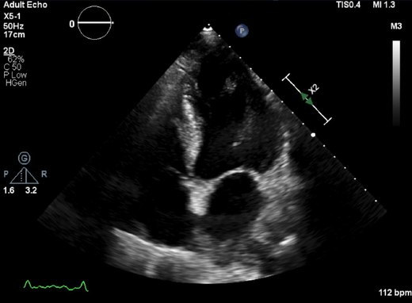

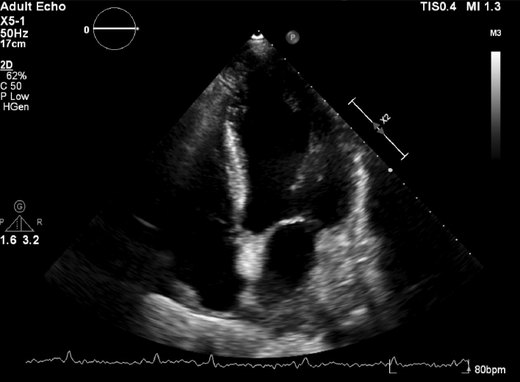

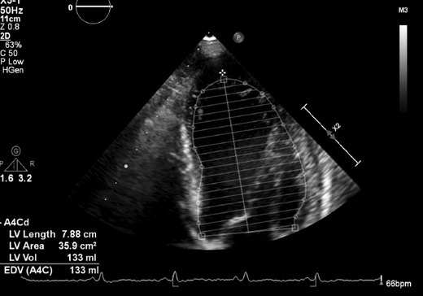

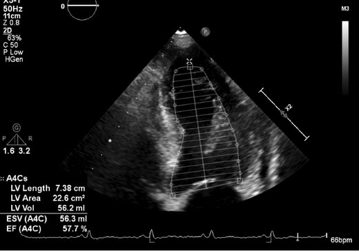

心尖四腔（舒張期 · 收縮期） │ EDV 133 mL │ ESV 56 mL · EF 57.7% │ 影像已去識別化

### 判讀重點：看心尖，不要只看整體 EF

心尖已無血栓；但心尖仍可見節段性室壁運動異常（WMSI 1.50），提醒基質仍在。 評估血栓風險時必須逐節段檢視心尖，必要時加打超音波顯影劑讓腔室邊界清楚呈現。

FOLLOW-UP TTE · 2024WMSI 1.50

心電圖

## 從頭到尾都是竇性心律

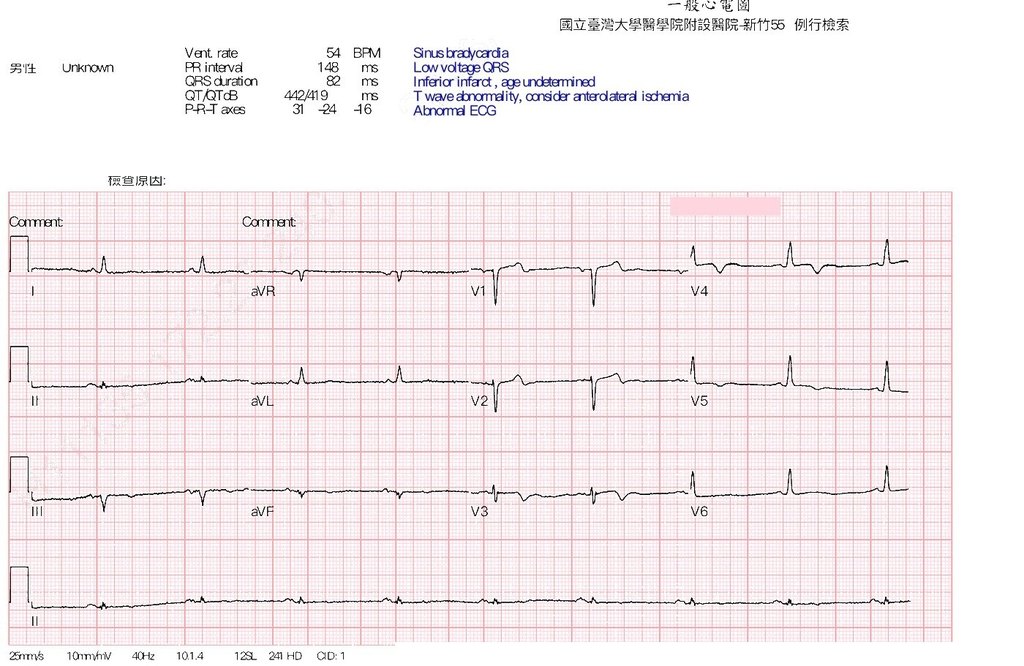

### Sinus bradycardia

竇性心律，從未記錄到心房顫動 —— 但他仍然是心因性栓塞。

### Inferior infarct · Low voltage

陳舊性梗塞與廣泛心肌疤痕留下的痕跡。

### Anterolateral ischemia (T)

前側壁的陳舊變化，提示 LAD 領域曾大範圍受損。

**心電圖的價值不只在找 Afib —— 它同時在告訴你「這顆心臟有沒有疤」。**

ECG · 54 BPMNO AF, EVER

2023.10

## 抗凝治療的另一面：消化道出血

誠實地把代價也放進教材，才知道怎麼避免。

### 事件經過

- 2023 年 10 月初因神經痛至神經科門診，開立一週 NSAID（diclofenac）。
- 隨後食慾變差、上腹痛、解黑便，急診就醫時發燒併心搏過速。
- 胃鏡：十二指腸球部潰瘍 Forrest IIb，接受腎上腺素注射與止血夾治療。

### 跨科用藥的四個提醒

- 開藥前確認病人是否在使用抗凝劑——用藥清單要真的打開來看。
- 需要止痛時，抗凝病人優先選 acetaminophen，避免 NSAID。
- 長期抗凝且有潰瘍病史者，應併用 PPI 保護。
- 抗凝穩定後，重新評估是否仍需併用抗血小板藥。

### 三重打擊

抗凝劑（warfarin） ＋ 抗血小板（Plavix） ＋ NSAID  
＝ 上消化道出血風險大幅升高

THE PRICEFORREST IIb

通則

## 誰會長出左心室血栓？

### 急性心肌梗塞後

- 前壁／心尖大範圍梗塞
- 心尖 akinesia、dyskinesia
- 心尖動脈瘤形成
- 再灌流延遲或失敗

### 心肌病變

- 擴張型心肌病變
- 缺血性心肌病變
- 心尖肥厚型心肌病變
- Takotsubo 症候群

### 發炎與浸潤

- 心肌炎
- 嗜伊紅性心肌炎
- 心臟類澱粉沉積
- 左心室緻密化不全

### 其他情境

- LVEF ≤ 35%
- 左心室輔助器（LVAD）
- 癌症、抗磷脂症候群
- COVID-19 等急性重症

### 共同點：Virchow 三要素在心尖同時成立

最常見、最好辨認、也最容易被忽略的組合就是本案例： **陳舊性前壁心肌梗塞 ＋ 心尖無運動／動脈瘤 ＋ LVEF 下降**。

HIGH-RISK SUBSTRATESVIRCHOW

通則

## 影像工具怎麼選？

| 工具 | 強項 | 限制／盲點 | 什麼時候用 |
| --- | --- | --- | --- |
| 一般 TTE | 第一線篩檢；便宜、可重複 | 對心尖血栓敏感度偏低（以 CMR 為標準約僅三成）；心尖易 foreshortening | 所有懷疑對象的起點，但陰性不足以排除 |
| 顯影 TTE | 讓左心室腔室邊界清楚，血栓呈現充盈缺損 | 需額外顯影劑與判讀經驗 | TTE 心尖顯影不佳、或高度懷疑時的必要加做 |
| TEE | 左心耳、心房中隔、主動脈弓、瓣膜的最佳窗口 | 左心室心尖位於遠場，最容易漏診 | 找左心耳血栓／PFO 用；**不適合用來排除心尖血栓** |
| 心臟 MRI（LGE） | 偵測左心室血栓的參考標準；同時顯示疤痕與存活心肌 | 取得不易、時間長、有金屬植入物限制 | 高度懷疑但超音波不確定時的確診工具；亦用於追蹤消退 |

### 一句話總結

要排除左心室心尖血栓，請用 TTE 心尖切面（必要時加顯影劑）或 CMR，不要用 TEE。

IMAGING STRATEGYTTE · UEA · CMR

給神經科

## 什麼時候該懷疑左心室血栓？

出現以下任一項，就該想到左心室。

病人有陳舊性心肌梗塞病史（特別是前壁／LAD 領域）

心電圖有病理性 Q 波、陳舊梗塞徵象或持續 ST 上升

已知 LVEF 下降、心衰竭、心尖動脈瘤

梗塞分佈與頸動脈／顱內血管病灶「對不上」

同時侵犯多個血管領域（前＋後循環，或雙側）

皮質型、楔形梗塞，型態像栓塞而非小血管病變

同時有周邊動脈栓塞（腎、脾、腸、肢體）

抗血小板治療下仍反覆發作

### 第一步

開 TTE，並在單子上明確註明：「請評估左心室心尖是否有血栓，必要時加做超音波顯影劑」。

### 第二步

若心尖顯影不佳或高度懷疑 → 顯影 TTE 或心臟 MRI 延遲增強。

### 別忘了

長時間心律監測仍應執行。心房顫動與左心室血栓可同時存在，找到一個不代表可停止找另一個。

WHEN TO SUSPECTORDER THE APEX

通則

## 抗凝治療：藥物選擇與療程

### Warfarin（維生素 K 拮抗劑）

- 證據最完整，指引長年建議的標準治療。
- INR 目標 2.0–3.0。
- 可監測、可逆轉；適合腎功能不佳、需確認遵囑性的病人。
- 缺點：需頻繁抽血，受飲食與藥物交互作用影響。

### DOAC（直接口服抗凝劑）

- 對此適應症屬仿單標示外（off-label）使用。
- 早期大型觀察研究曾顯示栓塞事件較 warfarin 多（Robinson, JAMA Cardiol 2020）。
- 近年小型 RCT 與統合分析顯示兩者相當，但事件數少、證據等級有限。
- AHA 2022 科學聲明列為可考慮的替代選項。

### 療程與追蹤

至少 3–6 個月，並以影像（顯影 TTE 或 CMR）確認血栓消退。若心尖動脈瘤／無運動持續存在、 LVEF 仍低、或已發生系統性栓塞，延長甚至長期抗凝是合理的。

### 急性中風期的兩難

剛發生大面積梗塞時立即抗凝會增加出血轉化風險。依梗塞大小與影像決定啟動時機 （小梗塞可較早、大梗塞延後數日至一兩週），並與神經科共同決策。

ANTICOAGULATIONINR 2.0–3.0 · 3–6 MO

結論 1／2

## 帶回去的六句話

01 沒有心房顫動 ≠ 不是心因性栓塞。 左心室和左心房一樣會長血栓。

02 陳舊性前壁心肌梗塞，就是左心室血栓的高風險標記。 看到病史裡的 old MI，心尖就必須被看過。

03 把梗塞位置畫回血管圖。 當梗塞區域與狹窄血管對不上、或跨越多個血管領域時，答案在上游。

TAKE HOME01 – 03

結論 2／2

## 帶回去的六句話

04 TEE 陰性不能排除左心室心尖血栓。 心尖是 TEE 的遠場盲點；請用 TTE 心尖切面、顯影 TTE 或心臟 MRI。

05 找到血栓就換武器：抗血小板 → 抗凝，INR 2.0–3.0。 並以影像追蹤是否消退，而不是憑感覺停藥。

06 抗凝的代價要主動管理。 避免 NSAID、給 PPI、定期重新評估是否還需要併用抗血小板藥。

TAKE HOME04 – 06

自我測驗

# 自我測驗 10 題

接下來每一頁一題。點選答案，解析會立刻出現。  
答錯不扣分，但請把解析看完——這比記住正確答案更重要。

鍵盤 ← → 翻頁 · 最後一頁會顯示成績

SELF-ASSESSMENT10 QUESTIONS

自我測驗 1 ／ 10

SELF-ASSESSMENTQ01 / 10

自我測驗 2 ／ 10

Q02

此案例在 2019 年做了經食道心臟超音波（TEE），報告為「無左心房／左心耳血栓、無 PFO/ASD、global LV contractility 良好」。四個月後的經胸心臟超音波（TTE）卻發現心尖部動脈瘤合併 1.0×0.78 cm 的左心室壁貼壁血栓、LVEF 39%。最合理的解釋是？

SELF-ASSESSMENTQ02 / 10

自我測驗 3 ／ 10

Q03

左心室壁貼壁血栓形成的病理機轉，最貼切的描述是？

SELF-ASSESSMENTQ03 / 10

自我測驗 4 ／ 10

Q04

下列哪一組特徵，屬於「心肌梗塞後左心室血栓」的最高風險族群？

SELF-ASSESSMENTQ04 / 10

自我測驗 5 ／ 10

Q05

關於左心室血栓的影像診斷，下列何者正確？

SELF-ASSESSMENTQ05 / 10

自我測驗 6 ／ 10

Q06

本案例確診左心室壁貼壁血栓後，門診當場啟動 warfarin，起始劑量 3.5 mg/day。依現行建議，INR 的治療目標應設定為？

SELF-ASSESSMENTQ06 / 10

自我測驗 7 ／ 10

Q07

關於左心室血栓使用 DOAC 取代 warfarin，目前證據最恰當的說法是？

SELF-ASSESSMENTQ07 / 10

自我測驗 8 ／ 10

Q08

此案例在 2023 年 10 月發生十二指腸潰瘍出血（Forrest IIb，接受腎上腺素注射與夾子止血）。回顧當時用藥，最重要的可避免誘因是？

SELF-ASSESSMENTQ08 / 10

自我測驗 9 ／ 10

Q09

左心室血栓消失後（本案例以心臟 MRI 證實），關於抗凝療程長度，下列敘述何者最合適？

SELF-ASSESSMENTQ09 / 10

自我測驗 10 ／ 10

Q10

身為神經科／內科醫師，從這個案例可以帶走的最重要臨床習慣是？

SELF-ASSESSMENTQ10 / 10

成績

## 你的作答結果

0 / 10

還沒開始作答。

逐題結果 · 綠色答對 · 紅色答錯

SELF-ASSESSMENTRESULT

延伸閱讀

## References

**Levine GN, McEvoy JW, Fang JC, et al.** Management of Patients at Risk for and With Left Ventricular Thrombus: A Scientific Statement From the AHA. Circulation. 2022;146(15):e205–e223

**Sharma R, Levine GN, Spinler SA, et al.** Management of Patients at Risk of Ischemic Stroke With LV Systolic Dysfunction in the Absence of Intracardiac Thrombus: AHA Scientific Statement. Stroke. 2026 Aug

**Weinsaft JW, Kim HW, Crowley AL, et al.** LV thrombus detection by routine echocardiography: insights into performance characteristics using delayed enhancement CMR. JACC Cardiovasc Imaging. 2011;4(7):702–712

**Robinson AA, Trankle CR, Eubanks G, et al.** Off-label Use of Direct Oral Anticoagulants Compared With Warfarin for Left Ventricular Thrombi. JAMA Cardiol. 2020;5(6):685–692

**Costa TA, Chagas GCL, Tavares de Sousa LM, et al.** DOAC versus warfarin in patients with a left ventricular thrombus: updated systematic review and meta-analysis of RCTs. Open Heart. 2025;12(2):e003542

**Kleindorfer DO, Towfighi A, Chaturvedi S, et al.** 2021 Guideline for the Prevention of Stroke in Patients With Stroke and Transient Ischemic Attack. Stroke. 2021;52(7):e364–e467

REFERENCES6 SOURCES

LV MURAL THROMBUS

如果找不到原因

# 就再看一次 左心室的心尖。

這位病人反覆中風六年；正確診斷之後，六年沒有再發作。

本教材為院內臨床教學使用，案例內容已去識別化。  
教材內容不取代臨床判斷；個別病人的治療決策請依當下臨床情境與最新指引為準。

謝謝聆聽 · 歡迎討論心臟內科 × 神經內科